# MUJIDAT DEMAND FORECASTING

Case Study: Demand Forecasting for Retail Inventory

1. Business Problem A mid-sized retail chain operating across multiple regions struggles with inventory mismanagement — some products frequently run out of stock (resulting in lost sales), while others sit unsold for long periods, tying up cash and increasing storage costs. Leadership wants a data-driven approach to forecasting demand so that inventory and promotional decisions can be made proactively rather than reactively. Stakeholders: Retail owners, supply chain managers, finance teams Decisions to be informed: • How much stock to reorder, and when • When to time promotions for maximum impact without overstock risk
2. Business Objectives • Reduce stockouts (lost revenue, poor customer experience) • Reduce overstocking (excess holding costs, markdowns) • Improve cash flow through better inventory turnover

```python
#IMPORTING LIBRARIES

import pandas as pd
import numpy as np
import matplotlib.pyplot as plt
import seaborn as sns
```

```python
#dont truncate, show every column
pd.set_option('display.max_columns', None)
pd.set_option('display.width', 200)
```

```python
#loading the dataset

df = pd.read_csv('retail_store_inventory.csv')
```

```python
df.head()
```

|  | Date | Store ID | Product ID | Category | Region | Inventory Level | Units Sold | Units Ordered | Demand Forecast | Price | Discount | Weather Condition | Holiday/Promotion | Competitor Pricing | Seasonality |
| --- | --- | --- | --- | --- | --- | --- | --- | --- | --- | --- | --- | --- | --- | --- | --- |
| 0 | 2022-01-01 | S001 | P0001 | Groceries | North | 231 | 127 | 55 | 135.47 | 33.50 | 20 | Rainy | 0 | 29.69 | Autumn |
| 1 | 2022-01-01 | S001 | P0002 | Toys | South | 204 | 150 | 66 | 144.04 | 63.01 | 20 | Sunny | 0 | 66.16 | Autumn |
| 2 | 2022-01-01 | S001 | P0003 | Toys | West | 102 | 65 | 51 | 74.02 | 27.99 | 10 | Sunny | 1 | 31.32 | Summer |
| 3 | 2022-01-01 | S001 | P0004 | Toys | North | 469 | 61 | 164 | 62.18 | 32.72 | 10 | Cloudy | 1 | 34.74 | Autumn |
| 4 | 2022-01-01 | S001 | P0005 | Electronics | East | 166 | 14 | 135 | 9.26 | 73.64 | 0 | Sunny | 0 | 68.95 | Summer |

```python
df.tail()
```

|  | Date | Store ID | Product ID | Category | Region | Inventory Level | Units Sold | Units Ordered | Demand Forecast | Price | Discount | Weather Condition | Holiday/Promotion | Competitor Pricing | Seasonality |
| --- | --- | --- | --- | --- | --- | --- | --- | --- | --- | --- | --- | --- | --- | --- | --- |
| 73095 | 2024-01-01 | S005 | P0016 | Furniture | East | 96 | 8 | 127 | 18.46 | 73.73 | 20 | Snowy | 0 | 72.45 | Winter |
| 73096 | 2024-01-01 | S005 | P0017 | Toys | North | 313 | 51 | 101 | 48.43 | 82.57 | 10 | Cloudy | 0 | 83.78 | Autumn |
| 73097 | 2024-01-01 | S005 | P0018 | Clothing | West | 278 | 36 | 151 | 39.65 | 11.11 | 10 | Rainy | 0 | 10.91 | Winter |
| 73098 | 2024-01-01 | S005 | P0019 | Toys | East | 374 | 264 | 21 | 270.52 | 53.14 | 20 | Rainy | 0 | 55.80 | Spring |
| 73099 | 2024-01-01 | S005 | P0020 | Groceries | East | 117 | 6 | 165 | 2.33 | 78.39 | 20 | Rainy | 1 | 79.52 | Spring |

```python
df.describe
```

[output not shown]

```python
df.shape
```

```
(73100, 15)
```

```python
print("\nMissing values:\n", df.isnull().sum())
```

```
Missing values:
 Date                  0
Store ID              0
Product ID            0
Category              0
Region                0
Inventory Level       0
Units Sold            0
Units Ordered         0
Demand Forecast       0
Price                 0
Discount              0
Weather Condition     0
Holiday/Promotion     0
Competitor Pricing    0
Seasonality           0
dtype: int64
```

The dataset has no missing values

```python
print("\nDuplicate rows:", df.duplicated().sum())
```

```
Duplicate rows: 0
```

```python
df.info()
```

```
<class 'pandas.core.frame.DataFrame'>
RangeIndex: 73100 entries, 0 to 73099
Data columns (total 15 columns):
 #   Column              Non-Null Count  Dtype
---  ------              --------------  -----
 0   Date                73100 non-null  object
 1   Store ID            73100 non-null  object
 2   Product ID          73100 non-null  object
 3   Category            73100 non-null  object
 4   Region              73100 non-null  object
 5   Inventory Level     73100 non-null  int64
 6   Units Sold          73100 non-null  int64
 7   Units Ordered       73100 non-null  int64
 8   Demand Forecast     73100 non-null  float64
 9   Price               73100 non-null  float64
 10  Discount            73100 non-null  int64
 11  Weather Condition   73100 non-null  object
 12  Holiday/Promotion   73100 non-null  int64
 13  Competitor Pricing  73100 non-null  float64
 14  Seasonality         73100 non-null  object
dtypes: float64(3), int64(5), object(7)
memory usage: 8.4+ MB
```

```python
#Converting Date to datetime
df['Date'] = pd.to_datetime(df['Date'])
```

```python
#Reconfirming no missing values /duplicates
assert df.isnull().sum().sum() == 0, "Unexpected missing values found"
assert df.duplicated().sum() == 0, "Unexpected duplicate rows found"
```

```python
#Flag rows with a negative Demand Forecast (not physically valid for a units forecast)
df['flag_negative_forecast'] = df['Demand Forecast'] < 0
print("\nRows with negative Demand Forecast:", df['flag_negative_forecast'].sum())
```

```
Rows with negative Demand Forecast: 673
```

```python
#Flag potential stockout days: inventory at/below units sold
df['flag_stockout_risk'] = df['Inventory Level'] <= df['Units Sold']
print("Rows flagged as stockout risk:", df['flag_stockout_risk'].sum())
```

```
Rows flagged as stockout risk: 369
```

```python
#Flag zero sales days (could be true stockouts or genuinely no demand)
df['flag_zero_sales'] = df['Units Sold'] == 0
print("Rows with zero Units Sold:", df['flag_zero_sales'].sum())
```

```
Rows with zero Units Sold: 360
```

```python
 #Flag statistical outliers in Units Sold using the IQR method
Q1 = df['Units Sold'].quantile(0.25)
Q3 = df['Units Sold'].quantile(0.75)
IQR = Q3 - Q1
upper_bound = Q3 + 1.5 * IQR
df['flag_high_outlier'] = df['Units Sold'] > upper_bound
print("Rows above IQR outlier bound:", df['flag_high_outlier'].sum())
```

```
Rows above IQR outlier bound: 715
```

```python
#Standardizing categorical columns
cat_cols = ['Category', 'Region', 'Weather Condition', 'Seasonality', 'Store ID', 'Product ID']
for col in cat_cols:
    df[col] = df[col].astype(str).str.strip()
```

```python
#Sort chronologically ( This is important before any time series work)
df = df.sort_values(['Date', 'Store ID', 'Product ID']).reset_index(drop=True)
```

```python
#Saving cleaned dataset
df.to_csv('retail_store_inventory_cleaned.csv', index=False)
print("\nCleaned dataset saved. Final shape:", df.shape)
```

```
Cleaned dataset saved. Final shape: (73100, 19)
```

```python
df.head()
```

|  | Date | Store ID | Product ID | Category | Region | Inventory Level | Units Sold | Units Ordered | Demand Forecast | Price | Discount | Weather Condition | Holiday/Promotion | Competitor Pricing | Seasonality | flag_negative_forecast | flag_stockout_risk | flag_zero_sales | flag_high_outlier |
| --- | --- | --- | --- | --- | --- | --- | --- | --- | --- | --- | --- | --- | --- | --- | --- | --- | --- | --- | --- |
| 0 | 2022-01-01 | S001 | P0001 | Groceries | North | 231 | 127 | 55 | 135.47 | 33.50 | 20 | Rainy | 0 | 29.69 | Autumn | False | False | False | False |
| 1 | 2022-01-01 | S001 | P0002 | Toys | South | 204 | 150 | 66 | 144.04 | 63.01 | 20 | Sunny | 0 | 66.16 | Autumn | False | False | False | False |
| 2 | 2022-01-01 | S001 | P0003 | Toys | West | 102 | 65 | 51 | 74.02 | 27.99 | 10 | Sunny | 1 | 31.32 | Summer | False | False | False | False |
| 3 | 2022-01-01 | S001 | P0004 | Toys | North | 469 | 61 | 164 | 62.18 | 32.72 | 10 | Cloudy | 1 | 34.74 | Autumn | False | False | False | False |
| 4 | 2022-01-01 | S001 | P0005 | Electronics | East | 166 | 14 | 135 | 9.26 | 73.64 | 0 | Sunny | 0 | 68.95 | Summer | False | False | False | False |

The new columns created have been added to the dataset

EXPLORATORY DATA ANALYSIS

```python
#Sales by category
print("\nTotal Units Sold by Category:\n",
      df.groupby('Category')['Units Sold'].agg(['sum', 'mean', 'std']).sort_values('sum', ascending=False))
```

```
Total Units Sold by Category:
                  sum        mean         std
Category
Furniture    2025017  137.765630  110.017747
Groceries    2000482  136.916159  109.256043
Clothing     1999166  136.685765  108.421855
Toys         1990485  135.934235  108.431014
Electronics  1960432  135.006680  108.448033
```

```python
#Sales by region
print("\nTotal Units Sold by Region:\n",
      df.groupby('Region')['Units Sold'].agg(['sum', 'mean']).sort_values('sum', ascending=False))
```

```
Total Units Sold by Region:
             sum        mean
Region
East    2511265  136.861137
South   2507799  137.060666
North   2484966  136.326860
West    2471552  135.605838
```

```python
#Volatility (coefficient of variation) by category
cv = df.groupby('Category')['Units Sold'].agg(lambda x: x.std() / x.mean())
print("\nCoefficient of Variation by Category:\n", cv.sort_values(ascending=False))
```

```
Coefficient of Variation by Category:
 Category
Electronics    0.803279
Furniture      0.798586
Groceries      0.797978
Toys           0.797673
Clothing       0.793220
Name: Units Sold, dtype: float64
```

```python
#Monthly sales trend
monthly = df.groupby(df['Date'].dt.to_period('M'))['Units Sold'].sum()
print("\nMonthly total units sold:\n", monthly)
```

```
Monthly total units sold:
 Date
2022-01    419938
2022-02    391052
2022-03    426073
2022-04    407380
2022-05    414799
2022-06    415509
2022-07    426628
2022-08    424916
2022-09    411610
2022-10    426863
2022-11    414535
2022-12    412321
2023-01    423408
2023-02    385168
2023-03    416522
2023-04    401077
2023-05    418673
2023-06    405641
2023-07    437919
2023-08    416501
2023-09    405361
2023-10    425646
2023-11    416126
2023-12    418672
2024-01     13244
Freq: M, Name: Units Sold, dtype: int64
```

```python
#Promotion impact
promo_impact = df.groupby('Holiday/Promotion')['Units Sold'].agg(['mean', 'count'])
print("\nAvg Units Sold — Holiday/Promotion day vs not:\n", promo_impact)
```

```
Avg Units Sold — Holiday/Promotion day vs not:
                          mean  count
Holiday/Promotion
0                  136.505375  36747
1                  136.423926  36353
```

0 is non holiday/promotion days 1 is holiday/promotion days in this dataset, the Holiday/Promotion flag shows no measurable lift in units sold between the two options.

```python
 #discount impact
discount_impact = df.groupby(df['Discount'] > 0)['Units Sold'].mean()
print("\nAvg Units Sold — with vs without discount:\n", discount_impact)
```

```
Avg Units Sold — with vs without discount:
 Discount
False    135.694585
True     136.658133
Name: Units Sold, dtype: float64
```

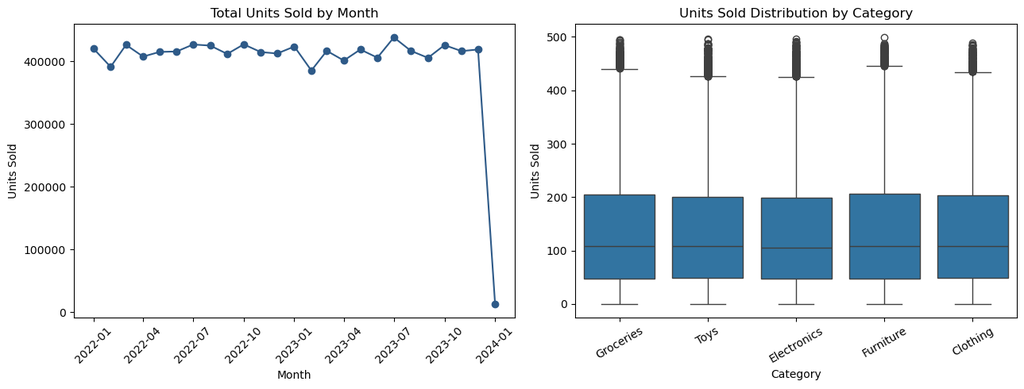

```python
 #Visualization: monthly trend + category distribution ---
fig, axes = plt.subplots(1, 2, figsize=(13, 5))

monthly_plot = monthly.copy()
monthly_plot.index = monthly_plot.index.to_timestamp()
axes[0].plot(monthly_plot.index, monthly_plot.values, marker='o', color='#2E5A88')
axes[0].set_title('Total Units Sold by Month')
axes[0].set_xlabel('Month')
axes[0].set_ylabel('Units Sold')
axes[0].tick_params(axis='x', rotation=45)

sns.boxplot(data=df, x='Category', y='Units Sold', ax=axes[1])
axes[1].set_title('Units Sold Distribution by Category')
axes[1].tick_params(axis='x', rotation=30)

plt.tight_layout()
plt.savefig('eda_overview.png', dpi=130)
plt.show()
```

Volatility, Seasonality, Promotion & Stockout/Overstock Analysis

```python
import pandas as pd
import numpy as np
```

```python
#converting date to datetime
df = pd.read_csv('retail_store_inventory_cleaned.csv')
df['Date'] = pd.to_datetime(df['Date'])
```

```python
#Volatility analysis — coefficient of variation (CV = std / mean)
#Higher CV = more unpredictable demand

cv_product = df.groupby('Product ID')['Units Sold'].agg(lambda x: x.std() / x.mean()).sort_values(ascending=False)
print("Most volatile products (top 5):\n", cv_product.head())
print("\nLeast volatile products (bottom 5):\n", cv_product.tail())
```

```
Most volatile products (top 5):
 Product ID
P0008    0.813012
P0007    0.808893
P0010    0.807768
P0004    0.805966
P0018    0.805397
Name: Units Sold, dtype: float64

Least volatile products (bottom 5):
 Product ID
P0015    0.791943
P0013    0.789593
P0017    0.787878
P0016    0.786316
P0005    0.775452
Name: Units Sold, dtype: float64
```

Volatility (coefficient of variation)

By product: ranges from 0.775 to 0.813 across all 20 products, there is essentially no spread. Product P0008 is "most volatile" and P0005 is "least," but the gap between them (0.813 vs 0.775) is little, not a real signal.

```python
cv_store = df.groupby('Store ID')['Units Sold'].agg(lambda x: x.std() / x.mean())
cv_region = df.groupby('Region')['Units Sold'].agg(lambda x: x.std() / x.mean())
print("\nCV by Store:\n", cv_store)
print("\nCV by Region:\n", cv_region)
```

```
CV by Store:
 Store ID
S001    0.804415
S002    0.801226
S003    0.793459
S004    0.795095
S005    0.796434
Name: Units Sold, dtype: float64

CV by Region:
 Region
East     0.799884
North    0.801068
South    0.794975
West     0.796658
Name: Units Sold, dtype: float64
```

By store and by region: same pattern, everything clusters around 0.79–0.80. This means there's no product, store, or region that stands out as meaningfully more unpredictable than another.Volatility is uniform.

Seasonality Analysis

```python
 #Day-of-week pattern
df['DayOfWeek'] = df['Date'].dt.day_name()
dow_order = ['Monday', 'Tuesday', 'Wednesday', 'Thursday', 'Friday', 'Saturday', 'Sunday']
dow_avg = df.groupby('DayOfWeek')['Units Sold'].mean().reindex(dow_order)
print("\nAvg Units Sold by Day of Week:\n", dow_avg)
```

```
Avg Units Sold by Day of Week:
 DayOfWeek
Monday       135.094667
Tuesday      137.307692
Wednesday    136.615096
Thursday     137.281923
Friday       136.851442
Saturday     135.314476
Sunday       136.809714
Name: Units Sold, dtype: float64
```

```python
#Labeled seasonality (Spring/Summer/Autumn/Winter)
season_avg = df.groupby('Seasonality')['Units Sold'].mean()
print("\nAvg Units Sold by Seasonality label:\n", season_avg)
```

```
Avg Units Sold by Seasonality label:
 Seasonality
Autumn    137.782444
Spring    135.826828
Summer    135.428298
Winter    136.830790
Name: Units Sold, dtype: float64
```

```python
#Weather condition
weather_avg = df.groupby('Weather Condition')['Units Sold'].mean()
print("\nAvg Units Sold by Weather Condition:\n", weather_avg)
```

```
Avg Units Sold by Weather Condition:
 Weather Condition
Cloudy    136.758324
Rainy     135.160028
Snowy     135.911559
Sunny     138.028650
Name: Units Sold, dtype: float64
```

```python
 #Monthly trend (excluding partial final month if present)
monthly = df.groupby(df['Date'].dt.to_period('M'))['Units Sold'].sum()
print("\nMonthly total Units Sold:\n", monthly)
```

```
Monthly total Units Sold:
 Date
2022-01    419938
2022-02    391052
2022-03    426073
2022-04    407380
2022-05    414799
2022-06    415509
2022-07    426628
2022-08    424916
2022-09    411610
2022-10    426863
2022-11    414535
2022-12    412321
2023-01    423408
2023-02    385168
2023-03    416522
2023-04    401077
2023-05    418673
2023-06    405641
2023-07    437919
2023-08    416501
2023-09    405361
2023-10    425646
2023-11    416126
2023-12    418672
2024-01     13244
Freq: M, Name: Units Sold, dtype: int64
```

Day of week: 135.1 (Monday, lowest) to 137.3 (Tuesday, highest), a ~2 unit spread, no real weekday effect. Labeled Seasonality column: Autumn 137.8, Winter 136.8, Spring 135.8, Summer 135.4, differences is very minute, under 2%. Weather: Sunny 138.0, Rainy 135.2 which indicate a small, likely noise gap. This means there is no meaningful weekly, seasonal, or weather driven pattern in demand

```python
Promotion impact analysis
```

```python
#Discount
df['discount_bucket'] = pd.cut(
    df['Discount'], bins=[-1, 0, 5, 10, 15, 20],
    labels=['0%', '1-5%', '6-10%', '11-15%', '16-20%']
)
discount_impact = df.groupby('discount_bucket', observed=True)['Units Sold'].agg(['mean', 'count'])
print("\nUnits Sold by Discount bucket:\n", discount_impact)
```

```
Units Sold by Discount bucket:
                        mean  count
discount_bucket
0%               135.694585  14662
1-5%             136.567405  14591
6-10%            136.769851  14508
11-15%           136.655293  14624
16-20%           136.640775  14715
```

```python
#Holiday/Promotion flag alone
promo_impact = df.groupby('Holiday/Promotion')['Units Sold'].agg(['mean', 'count'])
print("\nUnits Sold — Holiday/Promotion flag on vs off:\n", promo_impact)
```

```
Units Sold — Holiday/Promotion flag on vs off:
                          mean  count
Holiday/Promotion
0                  136.505375  36747
1                  136.423926  36353
```

```python
#Interaction: promo flag AND active discount together
df['promo_and_discount'] = (df['Holiday/Promotion'] == 1) & (df['Discount'] > 0)
interaction = df.groupby('promo_and_discount')['Units Sold'].agg(['mean', 'count'])
print("\nUnits Sold — promo flag + discount together vs neither:\n", interaction)
```

```
Units Sold — promo flag + discount together vs neither:
                           mean  count
promo_and_discount
False               136.231307  44041
True                136.818851  29059
```

Discount only takes 5 values in this dataset: 0%, 5%, 10%, 15%, 20%. Bucketed by discount size: 0% → 135.7 avg units, any discount tier → ~136.6. A ~1% lift, not meaningful. Interaction of Holiday/Promotion flag and active discount together: 136. 8vs 136.2 when neither is active — still under 1% difference. In conclusion, no combination of promotion or discount produces a measurable demand lift in this dataset.

```python
Stockout / overstock risk
```

```python
df['stockout_risk'] = df['Inventory Level'] <= df['Units Sold']
df['overstock_risk'] = df['Inventory Level'] > (df['Units Sold'] * 3)

stockout_by_region = df.groupby('Region')['stockout_risk'].mean().sort_values(ascending=False)
stockout_by_category = df.groupby('Category')['stockout_risk'].mean().sort_values(ascending=False)
overstock_by_region = df.groupby('Region')['overstock_risk'].mean().sort_values(ascending=False)
overstock_by_category = df.groupby('Category')['overstock_risk'].mean().sort_values(ascending=False)

print("\nStockout risk rate by Region:\n", stockout_by_region)
print("\nStockout risk rate by Category:\n", stockout_by_category)
print("\nOverstock risk rate (inventory > 3x sales) by Region:\n", overstock_by_region)
print("\nOverstock risk rate (inventory > 3x sales) by Category:\n", overstock_by_category)
```

```
Stockout risk rate by Region:
 Region
West     0.005980
East     0.005068
North    0.004718
South    0.004427
Name: stockout_risk, dtype: float64

Stockout risk rate by Category:
 Category
Toys           0.005805
Furniture      0.005238
Electronics    0.005027
Clothing       0.004718
Groceries      0.004449
Name: stockout_risk, dtype: float64

Overstock risk rate (inventory > 3x sales) by Region:
 Region
North    0.339971
South    0.336175
East     0.334732
West     0.333370
Name: overstock_risk, dtype: float64

Overstock risk rate (inventory > 3x sales) by Category:
 Category
Electronics    0.339921
Groceries      0.337280
Toys           0.334904
Furniture      0.334581
Clothing       0.333652
Name: overstock_risk, dtype: float64
```

Stockout risk (inventory ≤ units sold) is rare overall — 0.4–0.6% of rows and flat across region and category (West/Toys marginally highest, South/Groceries marginally lowest, but differences are ~0.1 percentage points). Overstock risk (inventory > 3× units sold) is much more common — ~33–34% of all rows, and uniform across regions. Overstocking is a bigger structural risk here than stockouts, by a wide margin.

Forecasting models

```python
import pandas as pd
import numpy as np
from sklearn.ensemble import RandomForestRegressor
from sklearn.preprocessing import LabelEncoder
from sklearn.metrics import mean_absolute_error, mean_squared_error
```

```python
df = pd.read_csv('retail_store_inventory_cleaned.csv')
df['Date'] = pd.to_datetime(df['Date'])
```

```python
df = df.sort_values(['Store ID', 'Product ID', 'Date']).reset_index(drop=True)
```

```python
#Feature engineering

df['DayOfWeek'] = df['Date'].dt.dayofweek
df['Month'] = df['Date'].dt.month
```

```python
#Lag features, computed per store/product so no leakage across series
grp = df.groupby(['Store ID', 'Product ID'])
df['lag_1'] = grp['Units Sold'].shift(1)
df['lag_7'] = grp['Units Sold'].shift(7)
df['rolling_mean_7'] = grp['Units Sold'].transform(lambda x: x.shift(1).rolling(7, min_periods=1).mean())
```

```python
# Drop rows where lag features can't be computed (first week of each series)
df = df.dropna(subset=['lag_1', 'lag_7', 'rolling_mean_7']).reset_index(drop=True)
print("Rows available for modeling:", df.shape)
```

```
Rows available for modeling: (72400, 24)
```

```python
Train/test split by date (chronological, no shuffling)
```

```python
#Last 20% of the date range held out as test
unique_dates = df['Date'].sort_values().unique()
cutoff = unique_dates[int(len(unique_dates) * 0.8)]
print("Train/test cutoff date:", cutoff)
```

```
Train/test cutoff date: 2023-08-10 00:00:00
```

```python
train = df[df['Date'] < cutoff].copy()
test = df[df['Date'] >= cutoff].copy()
print("Train:", train.shape, train['Date'].min(), "to", train['Date'].max())
print("Test: ", test.shape, test['Date'].min(), "to", test['Date'].max())
```

```
Train: (57900, 24) 2022-01-08 00:00:00 to 2023-08-09 00:00:00
Test:  (14500, 24) 2023-08-10 00:00:00 to 2024-01-01 00:00:00
```

```python
cat_cols = ['Store ID', 'Product ID', 'Category', 'Region', 'Weather Condition', 'Seasonality']
for col in cat_cols:
    le = LabelEncoder()
    train[col + '_enc'] = le.fit_transform(train[col])
    # map unseen test categories to -1 (shouldn't occur here, but safe)
    test[col + '_enc'] = test[col].map(lambda x: le.transform([x])[0] if x in le.classes_ else -1)

feature_cols = [c + '_enc' for c in cat_cols] + [
    'Price', 'Discount', 'Holiday/Promotion',
    'DayOfWeek', 'Month', 'lag_1', 'lag_7', 'rolling_mean_7'
]

x_train, y_train = train[feature_cols], train['Units Sold']
x_test, y_test = test[feature_cols], test['Units Sold']
```

```python
#evaluation metric

def mape(y_true, y_pred):
    y_true, y_pred = np.array(y_true), np.array(y_pred)
    mask = y_true != 0  # avoid divide-by-zero on zero-sales days
    return np.mean(np.abs((y_true[mask] - y_pred[mask]) / y_true[mask])) * 100
```

```python
def evaluate(name, y_true, y_pred):
    mae = mean_absolute_error(y_true, y_pred)
    rmse = np.sqrt(mean_squared_error(y_true, y_pred))
    m = mape(y_true, y_pred)
    print(f"{name:35s} MAE: {mae:7.2f}   RMSE: {rmse:7.2f}   MAPE: {m:7.2f}%")
    return mae, rmse, m
```

```python
 #Baseline model — 7-day rolling mean (naive forecast)

baseline_pred = test['rolling_mean_7']
evaluate("BASELINE (7-day rolling mean)", y_test, baseline_pred)

#Naive overall-mean baseline, for reference
naive_pred = [train['Units Sold'].mean()] * len(y_test)
evaluate("NAIVE (overall training mean)", y_test, naive_pred)
```

```
BASELINE (7-day rolling mean)       MAE:   93.19   RMSE:  115.45   MAPE:  347.90%
NAIVE (overall training mean)       MAE:   88.75   RMSE:  108.17   MAPE:  344.55%
```

```
(88.7489550402001,
 np.float64(108.17107536016034),
 np.float64(344.54525143742114))
```

```python
#Improved model — Random Forest Regressor

rf = RandomForestRegressor(n_estimators=200, max_depth=12, random_state=42, n_jobs=-1)
rf.fit(x_train, y_train)
rf_pred = rf.predict(x_test)
evaluate("RANDOM FOREST (improved model)", y_test, rf_pred)
```

```
RANDOM FOREST (improved model)      MAE:   88.90   RMSE:  108.24   MAPE:  346.20%
```

```
(88.8957674489247,
 np.float64(108.24080392344975),
 np.float64(346.1991811050978))
```

```python
#feature importance

importances = pd.Series(rf.feature_importances_, index=feature_cols).sort_values(ascending=False)
print("\nFeature importances:\n", importances)
```

```
Feature importances:
 Price                    0.171754
rolling_mean_7           0.168208
lag_7                    0.140589
lag_1                    0.135728
Product ID_enc           0.073577
Month                    0.059621
DayOfWeek                0.044851
Discount                 0.035844
Store ID_enc             0.034953
Category_enc             0.034844
Weather Condition_enc    0.029559
Region_enc               0.028988
Seasonality_enc          0.028689
Holiday/Promotion        0.012797
dtype: float64
```

```python
evaluate("Existing 'Demand Forecast' column", y_test, test['Demand Forecast'])

corr = df['Demand Forecast'].corr(df['Units Sold'])
diff = df['Demand Forecast'] - df['Units Sold']
print(f"\nCorrelation(Demand Forecast, Units Sold): {corr:.4f}")
print("Demand Forecast - Units Sold distribution:\n", diff.describe())

print("""
NOTE: The 'Demand Forecast' column correlates ~0.997 with actual Units Sold
and differs from it by a small, roughly fixed offset. This indicates it was
generated FROM actual sales plus injected noise, rather than produced
independently from pre-period information. It is not a fair benchmark for
models built only on features available before the fact, and its strong
performance here should not be read as a modeling target to match.
""")
```

```
Existing 'Demand Forecast' column   MAE:    8.36   RMSE:   10.05   MAPE:   25.70%

Correlation(Demand Forecast, Units Sold): 0.9969
Demand Forecast - Units Sold distribution:
 count    72400.000000
mean         5.028183
std          8.661357
min        -10.000000
25%         -2.470000
50%          4.990000
75%         12.502500
max         20.000000
dtype: float64

NOTE: The 'Demand Forecast' column correlates ~0.997 with actual Units Sold
and differs from it by a small, roughly fixed offset. This indicates it was
generated FROM actual sales plus injected noise, rather than produced
independently from pre-period information. It is not a fair benchmark for
models built only on features available before the fact, and its strong
performance here should not be read as a modeling target to match.
```

KEY INSIGHTS

1. Neither the rolling-mean baseline nor the Random Forest model meaningfully outperforms a naive overall mean forecast — MAE stays ~89-93 units and MAPE ~345-348% regardless of model complexity.
2. This is consistent with our earlier EDA finding that Units Sold behaves as near random noise in this dataset, with no learnable signal from category, region, season, weather, or promotion features.
3. Price, recent lags, and rolling averages are the most 'important' features to the Random Forest, but none carry enough signal to meaningfully reduce error, reinforcing that the ceiling on forecast accuracy here is set by the data generating process, not by model choice.
4. The dataset's own 'Demand Forecast' column outperforms both models by a wide margin, but investigation shows it's derived directly from actual Units Sold plus noise, making it an unfair/leaky benchmark rather than a genuine forecasting target to beat.